# BreastCancer-v3-Copy2

## Breast Cancer Prediction and Detection

### via Machine Learning and Deep Learning

### David Kinney - DSC680 - Spring 2021 - Professor Catherine Williams

```python
# Import packages
import pandas as pd
from pycaret.classification import *
```

## Breast Cancer Prediction - Machine Learning

```python
# Read the Breast Cancer Wisconsin (Diagnostic) dataset
df = pd.read_csv('./data/data.csv')
df.shape
```

```
(569, 33)
```

### Exploratory Data Analysis

```python
df.describe().T
```

|  | count | mean | std | min | 25% | 50% | 75% | max |
| --- | --- | --- | --- | --- | --- | --- | --- | --- |
| id | 569.0 | 3.037183e+07 | 1.250206e+08 | 8670.000000 | 869218.000000 | 906024.000000 | 8.813129e+06 | 9.113205e+08 |
| radius_mean | 569.0 | 1.412729e+01 | 3.524049e+00 | 6.981000 | 11.700000 | 13.370000 | 1.578000e+01 | 2.811000e+01 |
| texture_mean | 569.0 | 1.928965e+01 | 4.301036e+00 | 9.710000 | 16.170000 | 18.840000 | 2.180000e+01 | 3.928000e+01 |
| perimeter_mean | 569.0 | 9.196903e+01 | 2.429898e+01 | 43.790000 | 75.170000 | 86.240000 | 1.041000e+02 | 1.885000e+02 |
| area_mean | 569.0 | 6.548891e+02 | 3.519141e+02 | 143.500000 | 420.300000 | 551.100000 | 7.827000e+02 | 2.501000e+03 |
| smoothness_mean | 569.0 | 9.636028e-02 | 1.406413e-02 | 0.052630 | 0.086370 | 0.095870 | 1.053000e-01 | 1.634000e-01 |
| compactness_mean | 569.0 | 1.043410e-01 | 5.281276e-02 | 0.019380 | 0.064920 | 0.092630 | 1.304000e-01 | 3.454000e-01 |
| concavity_mean | 569.0 | 8.879932e-02 | 7.971981e-02 | 0.000000 | 0.029560 | 0.061540 | 1.307000e-01 | 4.268000e-01 |
| concave points_mean | 569.0 | 4.891915e-02 | 3.880284e-02 | 0.000000 | 0.020310 | 0.033500 | 7.400000e-02 | 2.012000e-01 |
| symmetry_mean | 569.0 | 1.811619e-01 | 2.741428e-02 | 0.106000 | 0.161900 | 0.179200 | 1.957000e-01 | 3.040000e-01 |
| fractal_dimension_mean | 569.0 | 6.279761e-02 | 7.060363e-03 | 0.049960 | 0.057700 | 0.061540 | 6.612000e-02 | 9.744000e-02 |
| radius_se | 569.0 | 4.051721e-01 | 2.773127e-01 | 0.111500 | 0.232400 | 0.324200 | 4.789000e-01 | 2.873000e+00 |
| texture_se | 569.0 | 1.216853e+00 | 5.516484e-01 | 0.360200 | 0.833900 | 1.108000 | 1.474000e+00 | 4.885000e+00 |
| perimeter_se | 569.0 | 2.866059e+00 | 2.021855e+00 | 0.757000 | 1.606000 | 2.287000 | 3.357000e+00 | 2.198000e+01 |
| area_se | 569.0 | 4.033708e+01 | 4.549101e+01 | 6.802000 | 17.850000 | 24.530000 | 4.519000e+01 | 5.422000e+02 |
| smoothness_se | 569.0 | 7.040979e-03 | 3.002518e-03 | 0.001713 | 0.005169 | 0.006380 | 8.146000e-03 | 3.113000e-02 |
| compactness_se | 569.0 | 2.547814e-02 | 1.790818e-02 | 0.002252 | 0.013080 | 0.020450 | 3.245000e-02 | 1.354000e-01 |
| concavity_se | 569.0 | 3.189372e-02 | 3.018606e-02 | 0.000000 | 0.015090 | 0.025890 | 4.205000e-02 | 3.960000e-01 |
| concave points_se | 569.0 | 1.179614e-02 | 6.170285e-03 | 0.000000 | 0.007638 | 0.010930 | 1.471000e-02 | 5.279000e-02 |
| symmetry_se | 569.0 | 2.054230e-02 | 8.266372e-03 | 0.007882 | 0.015160 | 0.018730 | 2.348000e-02 | 7.895000e-02 |
| fractal_dimension_se | 569.0 | 3.794904e-03 | 2.646071e-03 | 0.000895 | 0.002248 | 0.003187 | 4.558000e-03 | 2.984000e-02 |
| radius_worst | 569.0 | 1.626919e+01 | 4.833242e+00 | 7.930000 | 13.010000 | 14.970000 | 1.879000e+01 | 3.604000e+01 |
| texture_worst | 569.0 | 2.567722e+01 | 6.146258e+00 | 12.020000 | 21.080000 | 25.410000 | 2.972000e+01 | 4.954000e+01 |
| perimeter_worst | 569.0 | 1.072612e+02 | 3.360254e+01 | 50.410000 | 84.110000 | 97.660000 | 1.254000e+02 | 2.512000e+02 |
| area_worst | 569.0 | 8.805831e+02 | 5.693570e+02 | 185.200000 | 515.300000 | 686.500000 | 1.084000e+03 | 4.254000e+03 |
| smoothness_worst | 569.0 | 1.323686e-01 | 2.283243e-02 | 0.071170 | 0.116600 | 0.131300 | 1.460000e-01 | 2.226000e-01 |
| compactness_worst | 569.0 | 2.542650e-01 | 1.573365e-01 | 0.027290 | 0.147200 | 0.211900 | 3.391000e-01 | 1.058000e+00 |
| concavity_worst | 569.0 | 2.721885e-01 | 2.086243e-01 | 0.000000 | 0.114500 | 0.226700 | 3.829000e-01 | 1.252000e+00 |
| concave points_worst | 569.0 | 1.146062e-01 | 6.573234e-02 | 0.000000 | 0.064930 | 0.099930 | 1.614000e-01 | 2.910000e-01 |
| symmetry_worst | 569.0 | 2.900756e-01 | 6.186747e-02 | 0.156500 | 0.250400 | 0.282200 | 3.179000e-01 | 6.638000e-01 |
| fractal_dimension_worst | 569.0 | 8.394582e-02 | 1.806127e-02 | 0.055040 | 0.071460 | 0.080040 | 9.208000e-02 | 2.075000e-01 |
| Unnamed: 32 | 0.0 | NaN | NaN | NaN | NaN | NaN | NaN | NaN |

```python
df.info()
```

```
<class 'pandas.core.frame.DataFrame'>
RangeIndex: 569 entries, 0 to 568
Data columns (total 33 columns):
 #   Column                   Non-Null Count  Dtype
---  ------                   --------------  -----
 0   id                       569 non-null    int64
 1   diagnosis                569 non-null    object
 2   radius_mean              569 non-null    float64
 3   texture_mean             569 non-null    float64
 4   perimeter_mean           569 non-null    float64
 5   area_mean                569 non-null    float64
 6   smoothness_mean          569 non-null    float64
 7   compactness_mean         569 non-null    float64
 8   concavity_mean           569 non-null    float64
 9   concave points_mean      569 non-null    float64
```

[output cut: 25 more lines]

```python
df.drop(['Unnamed: 32'], axis=1, inplace=True)
```

### Machine Learning Model Selection, Training and Tuning

#### PyCaret

PyCaret is an open-source, low-code machine learning library in Python that automates machine learning workflows. It is an end-to-end machine learning and model management tool that speeds up the experiment cycle exponentially and makes you more productive.

In comparison with the other open-source machine learning libraries, PyCaret is an alternate low-code library that can be used to replace hundreds of lines of code with few words only. This makes experiments exponentially fast and efficient. PyCaret is essentially a Python wrapper around several machine learning libraries and frameworks such as scikit-learn, XGBoost, LightGBM, CatBoost, spaCy, Optuna, Hyperopt, Ray, and many more.

(Source: https://pycaret.readthedocs.io/en/latest/index.html)

**Functions used**

- `setup` - initializes the environment in pycaret and creates the transformation pipeline to prepare the data for modeling and deployment.
- `compare_models` - trains all models in the model library and scores them using stratified cross validation for metric evaluation.
- `create_model` - trains and evaluates a model using cross validation.
- `tune_model` - automatically tunes the hyperparameters of a model using Random Grid Search on a pre-defined search space.
- `plot_model` - used to analyze the performance across different aspects such as AUC, confusion_matrix, decision boundary etc. This function takes a trained model object and returns a plot based on the test / hold-out set.
- `predict_model` - predict against the hold-out sample and evaluate the metrics to see if they are materially different than the CV results.

#### Initialize PyCaret

```python
clf1 = setup(df, target = 'diagnosis')
```

|  | Description | Value |
| --- | --- | --- |
| 0 | session_id | 2441 |
| 1 | Target | diagnosis |
| 2 | Target Type | Binary |
| 3 | Label Encoded | B: 0, M: 1 |
| 4 | Original Data | (569, 32) |
| 5 | Missing Values | False |
| 6 | Numeric Features | 31 |
| 7 | Categorical Features | 0 |
| 8 | Ordinal Features | False |
| 9 | High Cardinality Features | False |
| 10 | High Cardinality Method | None |
| 11 | Transformed Train Set | (398, 30) |
| 12 | Transformed Test Set | (171, 30) |
| 13 | Shuffle Train-Test | True |
| 14 | Stratify Train-Test | False |
| 15 | Fold Generator | StratifiedKFold |
| 16 | Fold Number | 10 |
| 17 | CPU Jobs | -1 |
| 18 | Use GPU | False |
| 19 | Log Experiment | False |
| 20 | Experiment Name | clf-default-name |
| 21 | USI | a317 |
| 22 | Imputation Type | simple |
| 23 | Iterative Imputation Iteration | None |
| 24 | Numeric Imputer | mean |
| 25 | Iterative Imputation Numeric Model | None |
| 26 | Categorical Imputer | constant |
| 27 | Iterative Imputation Categorical Model | None |
| 28 | Unknown Categoricals Handling | least_frequent |
| 29 | Normalize | False |
| 30 | Normalize Method | None |
| 31 | Transformation | False |
| 32 | Transformation Method | None |
| 33 | PCA | False |
| 34 | PCA Method | None |
| 35 | PCA Components | None |
| 36 | Ignore Low Variance | False |
| 37 | Combine Rare Levels | False |
| 38 | Rare Level Threshold | None |
| 39 | Numeric Binning | False |
| 40 | Remove Outliers | False |
| 41 | Outliers Threshold | None |
| 42 | Remove Multicollinearity | False |
| 43 | Multicollinearity Threshold | None |
| 44 | Clustering | False |
| 45 | Clustering Iteration | None |
| 46 | Polynomial Features | False |
| 47 | Polynomial Degree | None |
| 48 | Trignometry Features | False |
| 49 | Polynomial Threshold | None |
| 50 | Group Features | False |
| 51 | Feature Selection | False |
| 52 | Feature Selection Method | classic |
| 53 | Features Selection Threshold | None |
| 54 | Feature Interaction | False |
| 55 | Feature Ratio | False |
| 56 | Interaction Threshold | None |
| 57 | Fix Imbalance | False |
| 58 | Fix Imbalance Method | SMOTE |

#### Compare Baseline

```python
%%time
best_model = compare_models()
```

|  | Model | Accuracy | AUC | Recall | Prec. | F1 | Kappa | MCC | TT (Sec) |
| --- | --- | --- | --- | --- | --- | --- | --- | --- | --- |
| catboost | CatBoost Classifier | 0.9724 | 0.9967 | 0.9500 | 0.9729 | 0.9594 | 0.9386 | 0.9408 | 2.4360 |
| xgboost | Extreme Gradient Boosting | 0.9650 | 0.9956 | 0.9429 | 0.9571 | 0.9479 | 0.9217 | 0.9238 | 0.0550 |
| ada | Ada Boost Classifier | 0.9648 | 0.9923 | 0.9352 | 0.9647 | 0.9478 | 0.9213 | 0.9236 | 0.0230 |
| lda | Linear Discriminant Analysis | 0.9648 | 0.9880 | 0.9060 | 0.9917 | 0.9458 | 0.9199 | 0.9231 | 0.0050 |
| et | Extra Trees Classifier | 0.9647 | 0.9968 | 0.9352 | 0.9648 | 0.9481 | 0.9215 | 0.9235 | 0.0600 |
| gbc | Gradient Boosting Classifier | 0.9623 | 0.9945 | 0.9429 | 0.9529 | 0.9451 | 0.9165 | 0.9195 | 0.0460 |
| qda | Quadratic Discriminant Analysis | 0.9622 | 0.9935 | 0.9643 | 0.9336 | 0.9473 | 0.9180 | 0.9199 | 0.0050 |
| ridge | Ridge Classifier | 0.9597 | 0.0000 | 0.8989 | 0.9846 | 0.9384 | 0.9087 | 0.9122 | 0.0150 |
| lightgbm | Light Gradient Boosting Machine | 0.9597 | 0.9958 | 0.9280 | 0.9581 | 0.9407 | 0.9103 | 0.9129 | 0.2210 |
| rf | Random Forest Classifier | 0.9522 | 0.9917 | 0.9286 | 0.9383 | 0.9306 | 0.8943 | 0.8975 | 0.0620 |
| dt | Decision Tree Classifier | 0.9221 | 0.9173 | 0.9000 | 0.8840 | 0.8878 | 0.8285 | 0.8330 | 0.0080 |
| knn | K Neighbors Classifier | 0.7110 | 0.7603 | 0.4341 | 0.6252 | 0.5092 | 0.3139 | 0.3264 | 0.0180 |
| lr | Logistic Regression | 0.6533 | 0.5480 | 0.0000 | 0.0000 | 0.0000 | 0.0000 | 0.0000 | 0.6560 |
| nb | Naive Bayes | 0.6483 | 0.8944 | 0.0148 | 0.1500 | 0.0267 | -0.0007 | -0.0052 | 0.0030 |
| svm | SVM - Linear Kernel | 0.5600 | 0.0000 | 0.3000 | 0.1033 | 0.1537 | 0.0000 | 0.0000 | 0.0160 |

```
Wall time: 41.5 s
```

**Create best model from baseline results**

```python
%%time
model = create_model('catboost')
```

|  | Accuracy | AUC | Recall | Prec. | F1 | Kappa | MCC |
| --- | --- | --- | --- | --- | --- | --- | --- |
| 0 | 0.9500 | 1.0000 | 0.8571 | 1.0000 | 0.9231 | 0.8864 | 0.8921 |
| 1 | 1.0000 | 1.0000 | 1.0000 | 1.0000 | 1.0000 | 1.0000 | 1.0000 |
| 2 | 0.9750 | 1.0000 | 1.0000 | 0.9333 | 0.9655 | 0.9459 | 0.9473 |
| 3 | 0.9500 | 0.9863 | 0.8571 | 1.0000 | 0.9231 | 0.8864 | 0.8921 |
| 4 | 0.9500 | 0.9945 | 0.8571 | 1.0000 | 0.9231 | 0.8864 | 0.8921 |
| 5 | 1.0000 | 1.0000 | 1.0000 | 1.0000 | 1.0000 | 1.0000 | 1.0000 |
| 6 | 0.9250 | 0.9890 | 0.9286 | 0.8667 | 0.8966 | 0.8378 | 0.8391 |
| 7 | 1.0000 | 1.0000 | 1.0000 | 1.0000 | 1.0000 | 1.0000 | 1.0000 |
| 8 | 0.9744 | 0.9970 | 1.0000 | 0.9286 | 0.9630 | 0.9434 | 0.9449 |
| 9 | 1.0000 | 1.0000 | 1.0000 | 1.0000 | 1.0000 | 1.0000 | 1.0000 |
| Mean | 0.9724 | 0.9967 | 0.9500 | 0.9729 | 0.9594 | 0.9386 | 0.9408 |
| SD | 0.0261 | 0.0049 | 0.0643 | 0.0447 | 0.0381 | 0.0579 | 0.0562 |

```
Wall time: 25.6 s
```

**Tune hyperparameters**

```python
%%time
tuned_model = tune_model(model)
```

|  | Accuracy | AUC | Recall | Prec. | F1 | Kappa | MCC |
| --- | --- | --- | --- | --- | --- | --- | --- |
| 0 | 0.9750 | 0.9945 | 0.9286 | 1.0000 | 0.9630 | 0.9441 | 0.9456 |
| 1 | 1.0000 | 1.0000 | 1.0000 | 1.0000 | 1.0000 | 1.0000 | 1.0000 |
| 2 | 0.9500 | 0.9973 | 0.9286 | 0.9286 | 0.9286 | 0.8901 | 0.8901 |
| 3 | 0.9000 | 0.9890 | 0.7143 | 1.0000 | 0.8333 | 0.7647 | 0.7868 |
| 4 | 0.9750 | 0.9780 | 0.9286 | 1.0000 | 0.9630 | 0.9441 | 0.9456 |
| 5 | 1.0000 | 1.0000 | 1.0000 | 1.0000 | 1.0000 | 1.0000 | 1.0000 |
| 6 | 0.9000 | 0.9890 | 0.8571 | 0.8571 | 0.8571 | 0.7802 | 0.7802 |
| 7 | 1.0000 | 1.0000 | 1.0000 | 1.0000 | 1.0000 | 1.0000 | 1.0000 |
| 8 | 0.9744 | 0.9970 | 0.9231 | 1.0000 | 0.9600 | 0.9412 | 0.9428 |
| 9 | 1.0000 | 1.0000 | 1.0000 | 1.0000 | 1.0000 | 1.0000 | 1.0000 |
| Mean | 0.9674 | 0.9945 | 0.9280 | 0.9786 | 0.9505 | 0.9264 | 0.9291 |
| SD | 0.0372 | 0.0068 | 0.0845 | 0.0457 | 0.0576 | 0.0845 | 0.0805 |

```
Wall time: 33 s
```

#### Plot Results

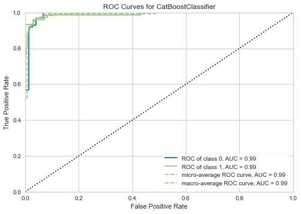

```python
plot_model(model)
```

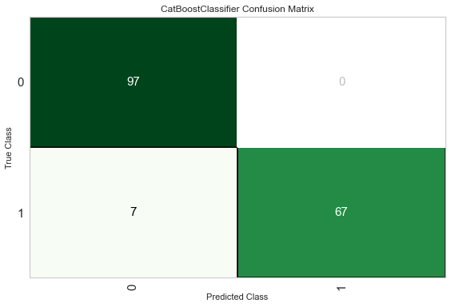

```python
plot_model(model, plot = 'confusion_matrix')
```

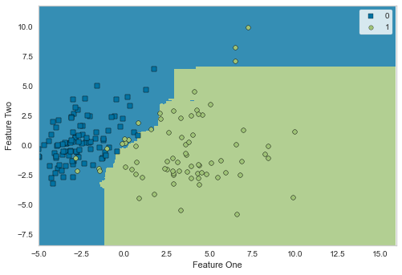

```python
plot_model(model, plot = 'boundary')
```

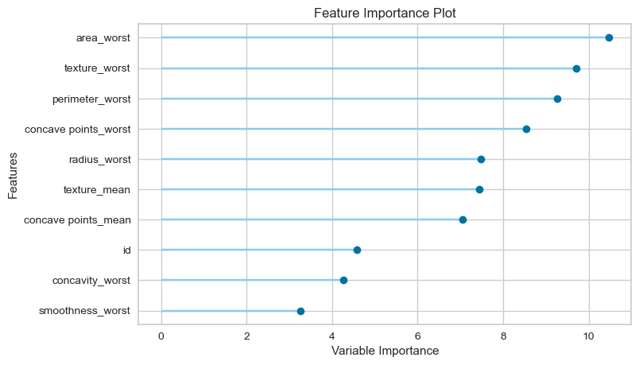

```python
plot_model(model, plot = 'feature')
```

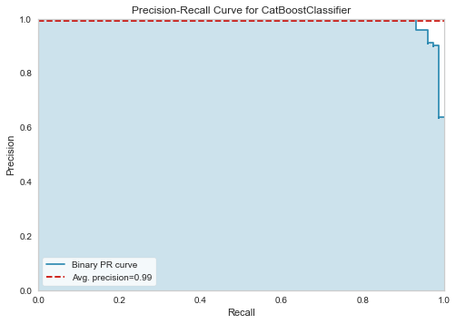

```python
plot_model(model, plot = 'pr')
```

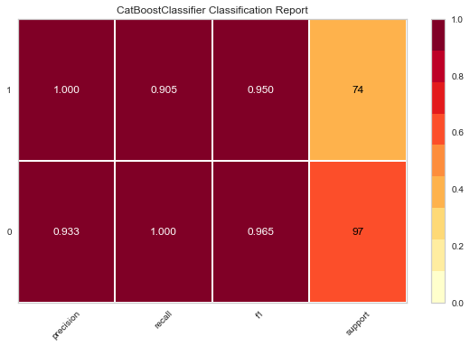

```python
plot_model(model, plot = 'class_report')
```

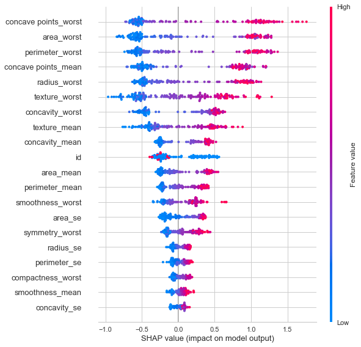

```python
interpret_model(model)
```

### Model Prediction

```python
pred_holdouts = predict_model(model)
pred_holdouts.head()
```

|  | Model | Accuracy | AUC | Recall | Prec. | F1 | Kappa | MCC |
| --- | --- | --- | --- | --- | --- | --- | --- | --- |
| 0 | CatBoost Classifier | 0.9591 | 0.9912 | 0.9054 | 1.0000 | 0.9504 | 0.9157 | 0.9189 |

|  | id | texture_mean | perimeter_mean | area_mean | smoothness_mean | compactness_mean | concavity_mean | concave points_mean | symmetry_mean | fractal_dimension_mean | ... | area_worst | smoothness_worst | compactness_worst | concavity_worst | concave points_worst | symmetry_worst | fractal_dimension_worst | diagnosis | Label | Score |
| --- | --- | --- | --- | --- | --- | --- | --- | --- | --- | --- | --- | --- | --- | --- | --- | --- | --- | --- | --- | --- | --- |
| 0 | 88147104.0 | 15.460000 | 66.620003 | 329.600006 | 0.10530 | 0.07722 | 0.006643 | 0.01216 | 0.1788 | 0.06450 | ... | 395.399994 | 0.1341 | 0.1153 | 0.02639 | 0.04464 | 0.2615 | 0.08269 | B | B | 0.9995 |
| 1 | 9012795.0 | 15.100000 | 141.300003 | 1386.000000 | 0.10010 | 0.15150 | 0.193200 | 0.12550 | 0.1973 | 0.06183 | ... | 1535.000000 | 0.1192 | 0.2840 | 0.40240 | 0.19660 | 0.2730 | 0.08666 | M | M | 0.9901 |
| 2 | 877500.0 | 20.219999 | 94.489998 | 642.700012 | 0.09872 | 0.12060 | 0.118000 | 0.05980 | 0.1950 | 0.06466 | ... | 1044.000000 | 0.1552 | 0.4056 | 0.49670 | 0.18380 | 0.4753 | 0.10130 | M | M | 0.9932 |
| 3 | 86408.0 | 20.760000 | 82.150002 | 480.399994 | 0.09933 | 0.12090 | 0.106500 | 0.06021 | 0.1735 | 0.07070 | ... | 527.400024 | 0.1287 | 0.2250 | 0.22160 | 0.11050 | 0.2226 | 0.08486 | B | B | 0.9532 |
| 4 | 912193.0 | 18.030001 | 78.290001 | 455.299988 | 0.09087 | 0.07838 | 0.029160 | 0.01527 | 0.1464 | 0.06284 | ... | 547.400024 | 0.1208 | 0.2279 | 0.16200 | 0.05690 | 0.2406 | 0.07729 | B | B | 0.9991 |

5 rows × 33 columns

Leveraging `PyCaret` results in a **model prediction accuracy of 96%** on the holdout set.

## Breast Cancer Detection - Deep Learning

### with fastai

```python
# Import packages
from os import listdir

import pandas as pd
import numpy as np

from fastai.callback.fp16 import *
from fastai.vision.all import *
from fastai import *
from fastai.metrics import error_rate
```

### Exploratory Data Analysis

```python
path = "./data/images/IDC_regular_ps50_idx5"
files = get_image_files(path)
len(files)
```

```
277524
```

**Load training data**

```python
pattern= r'([^/_]+).png$'
dls = ImageDataLoaders.from_path_re(path, files, pattern, item_tfms=Resize(50),
                                    bs=64, size=50, valid_pct=0.3, seed = 61)
```

```
Due to IPython and Windows limitation, python multiprocessing isn't available now.
So `number_workers` is changed to 0 to avoid getting stuck
```

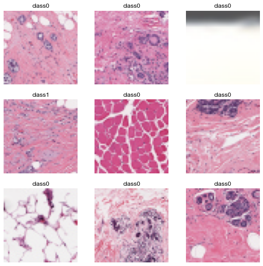

```python
# Class 0 = benign, class 1 = malignant
dls.show_batch()
```

### Modeling

I've been learning the [fastai](https://docs.fast.ai/) deep learning library, which also leverages `PyTorch`. The documentation is (IMHO) not well organized, but that is more than made up for with the online courses and the accompanying book. `fastai` streamlines much of the neural network modeling details, allowing me to simply supply model names such as `ResNet18` to the `cnn_learner` method. In addition, many of these models are pre-trained through *transfer learning*, requiring the model to only need to learn the weights of the last layer of the network.

```python
# fastai has a pretty cool feature that forces half-precision floating point
# precision training, effectively reducing GPU memory consumption: to_fp16
learn = cnn_learner(dls, models.resnet34, metrics=[accuracy]).to_fp16()
```

**As a baseline, I will run two different variations of the `fine-tune` method, which takes a pre-trained model and uses one epoch to fit just those parts necessary to fit my dataset.**

```python
%%time
# Run a simple fine-tune for 5 epochs
learn.fine_tune(5)
```

| epoch | train_loss | valid_loss | accuracy | time |
| --- | --- | --- | --- | --- |
| 0 | 0.341597 | 0.319248 | 0.862582 | 1:58:14 |

| epoch | train_loss | valid_loss | accuracy | time |
| --- | --- | --- | --- | --- |
| 0 | 0.272603 | 0.272337 | 0.886088 | 16:01 |
| 1 | 0.269025 | 0.255816 | 0.894507 | 10:28 |
| 2 | 0.221711 | 0.248075 | 0.896165 | 11:11 |
| 3 | 0.127272 | 0.298969 | 0.893546 | 11:01 |
| 4 | 0.058947 | 0.411077 | 0.889571 | 11:13 |

```
Wall time: 2h 58min 11s
```

```python
learn.save('BCPD_Simple5')
```

```
Path('data/images/IDC_regular_ps50_idx5/models/BCPD_Simple5.pth')
```

```python
learn.load('BCPD_Simple5')
```

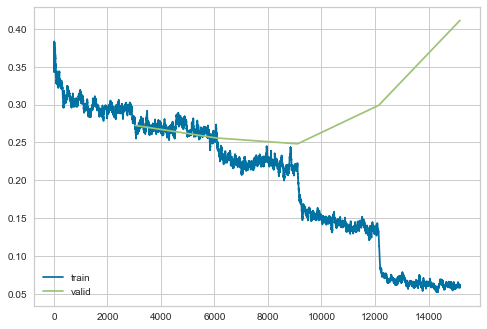

```python
learn.recorder.plot_loss()
```

**Accuracy peaks at 3 epochs, so we only need to train that far. 89.6% accuracy is good, but I'd really like to see it break 90. I am going to retrain the model on only 3 epochs and then unfreeze all the weights and train the whole model again...**

```python
%%time
learn.fine_tune(3)
```

| epoch | train_loss | valid_loss | accuracy | time |
| --- | --- | --- | --- | --- |
| 0 | 0.348063 | 0.320960 | 0.862846 | 14:40 |

| epoch | train_loss | valid_loss | accuracy | time |
| --- | --- | --- | --- | --- |
| 0 | 0.291008 | 0.268660 | 0.885679 | 11:49 |
| 1 | 0.237887 | 0.245006 | 0.897498 | 11:08 |
| 2 | 0.178940 | 0.254605 | 0.896862 | 10:32 |

```
Wall time: 48min 10s
```

[output not shown]

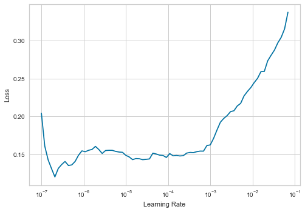

```python
%%time
# Hypermaramter tuning
learn.unfreeze()
learn.lr_find()
learn.recorder.plot()
```

```python
learn.fit_one_cycle(1,slice(1e-7,1e-3))
```

| epoch | train_loss | valid_loss | accuracy | time |
| --- | --- | --- | --- | --- |
| 0 | 0.144758 | 0.276781 | 0.895432 | 11:00 |

**Unfreezing the weights resulted in a slighly lower accuracy, but a fairly significant increase in validation loss. I expect this was overfitting, as the train loss went down while the validation loss went up. So I am going to use the previous model that was trained and tuned on 3 epochs.**

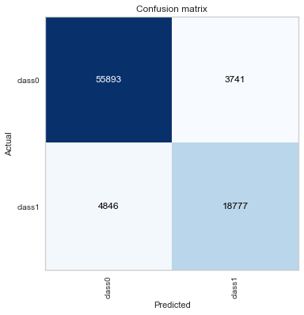

```python
interp = ClassificationInterpretation.from_learner(learn)
interp.plot_confusion_matrix()
```

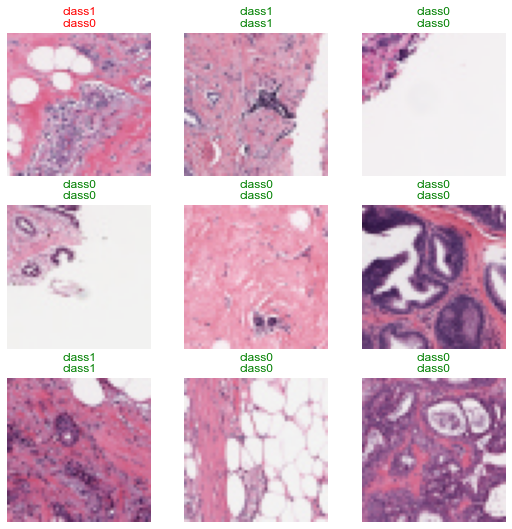

```python
learn.show_results()
```

```python
len(dls.valid_ds)
```

```
83257
```

```python
# Class 1 images in the validation set
4846+18777
```

```
23623
```

```python
# Calculate sensitivity and specificity
upp, low = interp.confusion_matrix()
tn, fp = upp[0], upp[1]
fn, tp = low[0], low[1]

# Sensitivity = True Positive/(True Positive + False Negative)
sensitivity = tp/(tp + fn)

# Specificity = True Negative/(False Positive + True Negative)
# aka Type II error
specificity = tn/(fp + tn)

# Positive Predictive Value aka Type I error
ppv = tp/(tp+fp)

# Negative Predictive Value
npv = tn/(tn+fn)

# Accuracy: sensitivity x prevalence + specificity * (1 - prevalence)
val = dls.valid_ds.cat


# There are 23,623 class 1 images in the valid set (which has a total of 83,257 images
# and can be checked by using len(dls.valid_ds)).
prevalence = 23623/83257
accuracy = sensitivity * prevalence + specificity * (1 - prevalence)

print("Sensitivity: {}".format(sensitivity))
print("Specificity: {}".format(specificity))
print("Accuracy: {}".format(accuracy))
print("PPV: {}".format(ppv))
print("NPV: {}".format(npv))
```

```
Sensitivity: 0.7948609406087288
Specificity: 0.937267330717376
Accuracy: 0.8968615251570438
PPV: 0.8338662403410605
NPV: 0.9202160061904213
```

**I am pretty happy with the final model results. While I never did get the accuracy to break 90%, the more important factor for me is a NPV of 92%. If my interpretation is correct, this model predicts false negatives at a rate of 8% (the prevailing rate for humans is closer to 20%!).**

#### Side notes on Results Evaluation

*(Note: this entire section was copied whole from [the fastai website](https://docs.fast.ai/tutorial.medical_imaging.html))*

Medical models are predominantly high impact so it is important to know how good a model is at detecting a certain condition.

`Accuracy` can be defined as the number of correctly predicted data points out of all the data points. However in this context we can define accuracy as the probability that the model is correct and the patient has the condition PLUS the probability that the model is correct and the patient *does not* have the condition.

**Calculating Accuracy**

**accuracy = sensitivity x prevalence + specificity * (1 - prevalence)**

Where **prevalence** is a statistical concept referring to the number of cases of a disease that are present in a particular population at a given time. The prevalence in this case is how many patients in the valid dataset have the condition compared to the total number.

There are some other key terms that need to be used when evaluating medical models:

**False Positive & False Negative**

- **False Positive** is an error in which a test result improperly indicates presence of a condition, such as a disease (the result is positive), when in reality it is not present
- **False Negative** is an error in which a test result improperly indicates no presence of a condition (the result is negative), when in reality it is present

**Sensitivity & Specificity**

- **Sensitivity or True Positive Rate** is where the model classifies a patient has the disease given the patient actually does have the disease. Sensitivity quantifies the avoidance of false negatives

Example: A new test was tested on 10,000 patients, if the new test has a sensitivity of 90% the test will correctly detect 9,000 (True Positive) patients but will miss 1000 (False Negative) patients that have the condition but were tested as not having the condition

- **Specificity or True Negative Rate** is where the model classifies a patient as not having the disease given the patient actually does not have the disease. Specificity quantifies the avoidance of false positives

[Understanding and using sensitivity, specificity and predictive values](https://www.ncbi.nlm.nih.gov/pmc/articles/PMC2636062/) is a great paper if you are interested in learning more about understanding sensitivity, specificity and predictive values.

**PPV and NPV**

Most medical testing is evaluated via PPV (Positive Predictive Value) or NPV (Negative Predictive Value).

**PPV** - if the model predicts a patient has a condition what is the probability that the patient actually has the condition

**NPV** - if the model predicts a patient does not have a condition what is the probability that the patient actually does not have the condition

The ideal value of the PPV, with a perfect test, is 1 (100%), and the worst possible value would be zero

The ideal value of the NPV, with a perfect test, is 1 (100%), and the worst possible value would be zero